# Python for data analysis - One Million Song Dataset

## Importing libraries and resources

```python
import os
import numpy as np
import pandas as pd
import matplotlib.pyplot as plt
import seaborn as sns
from matplotlib import rcParams
rcParams['figure.figsize'] = 10,7
rcParams['axes.grid'] = True
from sklearn.ensemble import RandomForestRegressor
from sklearn.linear_model import LogisticRegression
from sklearn.tree import DecisionTreeRegressor
from sklearn.ensemble import AdaBoostRegressor
from sklearn.neighbors import KNeighborsRegressor
from sklearn.neural_network import MLPRegressor
import matplotlib
from sklearn.decomposition import PCA
from sklearn import datasets, svm, metrics
from sklearn import preprocessing
from sklearn.utils import resample
import itertools
import scipy.stats
from sklearn.metrics import confusion_matrix
from sklearn.metrics import accuracy_score
from sklearn.model_selection import GridSearchCV

%matplotlib inline
```

## Importing data

```python
features = ['year', 'timbre1', 'timbre2', 'timbre3', 'timbre4', 'timbre5', 'timbre6', 'timbre7', 'timbre8', 'timbre9', 'timbre10', 'timbre11', 'timbre12', 'timbre13', 'timbre14', 'timbre15', 'timbre16', 'timbre17', 'timbre18', 'timbre19', 'timbre20', 'timbre21', 'timbre22', 'timbre23', 'timbre24', 'timbre25', 'timbre26', 'timbre27', 'timbre28', 'timbre29', 'timbre30', 'timbre31', 'timbre32', 'timbre33', 'timbre34', 'timbre35', 'timbre36 ', 'timbre37', 'timbre38', 'timbre39', 'timbre40', 'timbre41', 'timbre42', 'timbre43', 'timbre44', 'timbre45', 'timbre46', 'timbre47', 'timbre48', 'timbre49', 'timbre50', 'timbre51', 'timbre52', 'timbre53' , 'timbre54', 'timbre55', 'timbre56', 'timbre57', 'timbre58', 'timbre59', 'timbre60', 'timbre61', 'timbre62', 'timbre63', 'timbre64', 'timbre65', 'timbre66', 'timbre67', 'timbre68', 'timbre69', 'timbre70', 'timbre71', 'timbre72', 'timbre73', 'timbre74', 'timbre75', 'timbre76', 'timbre77', 'timbre78', 'timbre79', 'timbre80', 'timbre81', 'timbre82', 'timbre83', 'timbre84', 'timbre85', 'timbre86', 'timbre87', 'timbre88', 'timbre89', 'timbre90']
```

```python
data=pd.read_csv('/Users/luciedrevet/Documents/S7/Python for data analysis/Projet/YearPredictionMSD.csv', names=features)

print('the number of rows and colums are'+str(data.shape))
```

```
the number of rows and colums are(515345, 91)
```

## EDA

```python
data.info()
```

```
<class 'pandas.core.frame.DataFrame'>
RangeIndex: 515345 entries, 0 to 515344
Data columns (total 91 columns):
 #   Column     Non-Null Count   Dtype
---  ------     --------------   -----
 0   year       515345 non-null  int64
 1   timbre1    515345 non-null  float64
 2   timbre2    515345 non-null  float64
 3   timbre3    515345 non-null  float64
 4   timbre4    515345 non-null  float64
 5   timbre5    515345 non-null  float64
 6   timbre6    515345 non-null  float64
 7   timbre7    515345 non-null  float64
 8   timbre8    515345 non-null  float64
 9   timbre9    515345 non-null  float64
```

[output cut: 83 more lines]

No missing values that we have to delete, and we only have float value so we don't have to clean the data

```python
data.head(5)
```

|  | year | timbre1 | timbre2 | timbre3 | timbre4 | timbre5 | timbre6 | timbre7 | timbre8 | timbre9 | ... | timbre81 | timbre82 | timbre83 | timbre84 | timbre85 | timbre86 | timbre87 | timbre88 | timbre89 | timbre90 |
| --- | --- | --- | --- | --- | --- | --- | --- | --- | --- | --- | --- | --- | --- | --- | --- | --- | --- | --- | --- | --- | --- |
| 0 | 2001 | 49.94357 | 21.47114 | 73.07750 | 8.74861 | -17.40628 | -13.09905 | -25.01202 | -12.23257 | 7.83089 | ... | 13.01620 | -54.40548 | 58.99367 | 15.37344 | 1.11144 | -23.08793 | 68.40795 | -1.82223 | -27.46348 | 2.26327 |
| 1 | 2001 | 48.73215 | 18.42930 | 70.32679 | 12.94636 | -10.32437 | -24.83777 | 8.76630 | -0.92019 | 18.76548 | ... | 5.66812 | -19.68073 | 33.04964 | 42.87836 | -9.90378 | -32.22788 | 70.49388 | 12.04941 | 58.43453 | 26.92061 |
| 2 | 2001 | 50.95714 | 31.85602 | 55.81851 | 13.41693 | -6.57898 | -18.54940 | -3.27872 | -2.35035 | 16.07017 | ... | 3.03800 | 26.05866 | -50.92779 | 10.93792 | -0.07568 | 43.20130 | -115.00698 | -0.05859 | 39.67068 | -0.66345 |
| 3 | 2001 | 48.24750 | -1.89837 | 36.29772 | 2.58776 | 0.97170 | -26.21683 | 5.05097 | -10.34124 | 3.55005 | ... | 34.57337 | -171.70734 | -16.96705 | -46.67617 | -12.51516 | 82.58061 | -72.08993 | 9.90558 | 199.62971 | 18.85382 |
| 4 | 2001 | 50.97020 | 42.20998 | 67.09964 | 8.46791 | -15.85279 | -16.81409 | -12.48207 | -9.37636 | 12.63699 | ... | 9.92661 | -55.95724 | 64.92712 | -17.72522 | -1.49237 | -7.50035 | 51.76631 | 7.88713 | 55.66926 | 28.74903 |

5 rows × 91 columns

We probably would have to scale the data

```python
data.describe().T
```

|  | count | mean | std | min | 25% | 50% | 75% | max |
| --- | --- | --- | --- | --- | --- | --- | --- | --- |
| year | 515345.0 | 1998.397082 | 10.931046 | 1922.00000 | 1994.00000 | 2002.00000 | 2006.00000 | 2011.00000 |
| timbre1 | 515345.0 | 43.387126 | 6.067558 | 1.74900 | 39.95469 | 44.25850 | 47.83389 | 61.97014 |
| timbre2 | 515345.0 | 1.289554 | 51.580351 | -337.09250 | -26.05952 | 8.41785 | 36.12401 | 384.06573 |
| timbre3 | 515345.0 | 8.658347 | 35.268585 | -301.00506 | -11.46271 | 10.47632 | 29.76482 | 322.85143 |
| timbre4 | 515345.0 | 1.164124 | 16.322790 | -154.18358 | -8.48750 | -0.65284 | 8.78754 | 335.77182 |
| ... | ... | ... | ... | ... | ... | ... | ... | ... |
| timbre86 | 515345.0 | 17.669213 | 114.427905 | -3168.92457 | -31.58061 | 15.59847 | 67.79496 | 3662.06565 |
| timbre87 | 515345.0 | -26.315336 | 173.977336 | -4319.99232 | -101.53030 | -21.20412 | 52.38933 | 2833.60895 |
| timbre88 | 515345.0 | 4.458641 | 13.346557 | -236.03926 | -2.56609 | 3.11764 | 9.96774 | 463.41950 |
| timbre89 | 515345.0 | 20.035136 | 185.558247 | -7458.37815 | -59.50927 | 7.75973 | 86.35161 | 7393.39844 |
| timbre90 | 515345.0 | 1.329105 | 22.088576 | -381.42443 | -8.82021 | 0.05305 | 9.67952 | 677.89963 |

91 rows × 8 columns

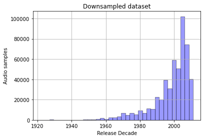

```python
sns.distplot(data['year'], hist=True, kde=False,
             bins=int(180/5), color = 'blue',
             hist_kws={'edgecolor':'black'})

plt.ylabel("Audio samples")
plt.xlabel("Release Decade")
plt.title("Downsampled dataset")
```

We notice that the frequency of the counts start to take off in the late 1970s to dawn of 1980s, likely coinciding with the invention of the CDs by Philips and Sony!

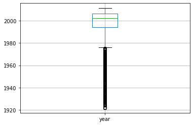

```python
boxplot = data.boxplot(column=['year'])
boxplot
```

```python
print("(Year, Features) {}".format(data.iloc[:,:1].shape))
data.iloc[:,:1].describe()
```

```
(Year, Features) (515345, 1)
```

|  | year |
| --- | --- |
| count | 515345.000000 |
| mean | 1998.397082 |
| std | 10.931046 |
| min | 1922.000000 |
| 25% | 1994.000000 |
| 50% | 2002.000000 |
| 75% | 2006.000000 |
| max | 2011.000000 |

What we can clearly see is that the central mass between the 1st and 3rd quartiles lies in years ranging from the mid 1990s to the mid 2000s.Let's see if there is a correlation between the features and the target

```
array([[<matplotlib.axes._subplots.AxesSubplot object at 0x7f8ef3e3a1c0>,
      dtype=object)
```

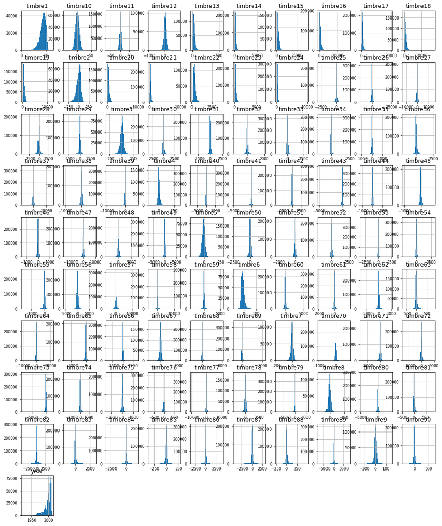

```python
data.hist(figsize=(16, 20), bins=50, xlabelsize=8, ylabelsize=8)
```

Timbre1 is the only variable that seems to share a similar shape with our target

```python
#We normalize the data
data.iloc[:,1:] = (data.iloc[:,1:]-data.iloc[:,1:].min())/(data.iloc[:,1:].max() - data.iloc[:,1:].min())
```

```python
data.describe()
```

|  | year | timbre1 | timbre2 | timbre3 | timbre4 | timbre5 | timbre6 | timbre7 | timbre8 | timbre9 | ... | timbre81 | timbre82 | timbre83 | timbre84 | timbre85 | timbre86 | timbre87 | timbre88 | timbre89 | timbre90 |
| --- | --- | --- | --- | --- | --- | --- | --- | --- | --- | --- | --- | --- | --- | --- | --- | --- | --- | --- | --- | --- | --- |
| count | 515345.000000 | 515345.000000 | 515345.000000 | 515345.000000 | 515345.000000 | 515345.000000 | 515345.000000 | 515345.000000 | 515345.000000 | 515345.000000 | ... | 515345.000000 | 515345.000000 | 515345.000000 | 515345.000000 | 515345.000000 | 515345.000000 | 515345.000000 | 515345.000000 | 515345.000000 | 515345.000000 |
| mean | 1998.397082 | 0.691420 | 0.469220 | 0.496370 | 0.317065 | 0.395025 | 0.291384 | 0.515292 | 0.354893 | 0.477338 | ... | 0.354641 | 0.487939 | 0.368868 | 0.649008 | 0.567965 | 0.466491 | 0.600212 | 0.343834 | 0.503537 | 0.361319 |
| std | 10.931046 | 0.100755 | 0.071524 | 0.056533 | 0.033315 | 0.051486 | 0.051839 | 0.040408 | 0.039970 | 0.038797 | ... | 0.025103 | 0.019795 | 0.024342 | 0.019669 | 0.026832 | 0.016751 | 0.024320 | 0.019081 | 0.012494 | 0.020852 |
| min | 1922.000000 | 0.000000 | 0.000000 | 0.000000 | 0.000000 | 0.000000 | 0.000000 | 0.000000 | 0.000000 | 0.000000 | ... | 0.000000 | 0.000000 | 0.000000 | 0.000000 | 0.000000 | 0.000000 | 0.000000 | 0.000000 | 0.000000 | 0.000000 |
| 25% | 1994.000000 | 0.634423 | 0.431296 | 0.464117 | 0.297366 | 0.363241 | 0.255425 | 0.492028 | 0.331428 | 0.455263 | ... | 0.340902 | 0.480489 | 0.356416 | 0.640192 | 0.556182 | 0.459281 | 0.589698 | 0.333791 | 0.498181 | 0.351738 |
| 50% | 2002.000000 | 0.705890 | 0.479105 | 0.499284 | 0.313357 | 0.396254 | 0.284665 | 0.516247 | 0.355178 | 0.477685 | ... | 0.349492 | 0.490235 | 0.366329 | 0.648116 | 0.568804 | 0.466188 | 0.600926 | 0.341917 | 0.502710 | 0.360114 |
| 75% | 2006.000000 | 0.765261 | 0.517524 | 0.530202 | 0.332624 | 0.427220 | 0.320143 | 0.539971 | 0.378515 | 0.500192 | ... | 0.362867 | 0.497739 | 0.378451 | 0.657254 | 0.581505 | 0.473829 | 0.611214 | 0.351711 | 0.508002 | 0.369201 |
| max | 2011.000000 | 1.000000 | 1.000000 | 1.000000 | 1.000000 | 1.000000 | 1.000000 | 1.000000 | 1.000000 | 1.000000 | ... | 1.000000 | 1.000000 | 1.000000 | 1.000000 | 1.000000 | 1.000000 | 1.000000 | 1.000000 | 1.000000 | 1.000000 |

8 rows × 91 columns

The min is 0 and the max is 1 for every featuresCorrelation matrix

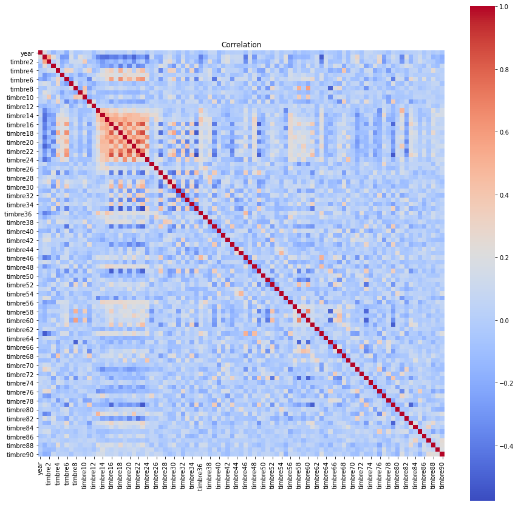

```python
corr = data.iloc[:,:].corr()
fig, ax = plt.subplots(figsize=(15,15))
plt.title("Correlation")
sns.heatmap(corr, square=True, cmap='coolwarm', annot=False)
plt.show()
```

We notice some important correlation around the variables timbre14 to timbre timbre24

```python
data.grouped=pd.read_csv('/Users/luciedrevet/Documents/S7/Python for data analysis/Projet/YearPredictionMSD.csv', names=features)
data.grouped['year'] = data.grouped.year.apply(lambda year : year-(year%10))
data.grouped.iloc[:,1:] = (data.grouped.iloc[:,1:]-data.grouped.iloc[:,1:].min())/(data.grouped.iloc[:,1:].max() - data.grouped.iloc[:,1:].min())
```

We group together by tens of yearsDoes the features differ by release decade ?

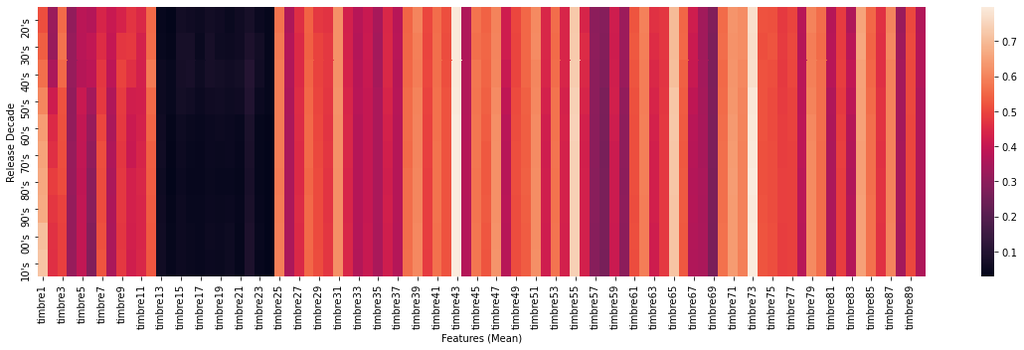

```python
columns = data.grouped.groupby(['year']).mean().columns
labels = ["{:02d}'s".format(l%100) for l in sorted(data.grouped.year.unique())]
fig, ax = plt.subplots(figsize=(20,5))
sns.heatmap(data.grouped.groupby(['year']).mean().iloc[:,:], yticklabels=labels)
plt.ylabel("Release Decade")
plt.xlabel("Features (Mean)")
plt.show()
```

We can see that exept for the variable 'timbre1', the features are pretty much the same by release decade...

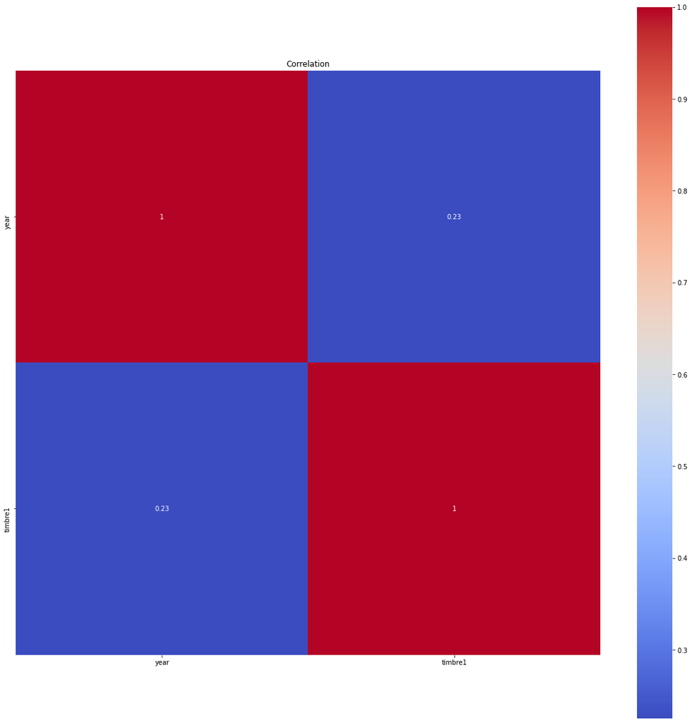

```python
# Correlation between the release decade and the timbre1 feature
corr = data.iloc[:,:2].corr()
fig, ax = plt.subplots(figsize=(20,20))
plt.title("Correlation")
sns.heatmap(corr, square=True, cmap='coolwarm', annot=True)
plt.show()
```

And the correlation is pretty low...

## Preprocessing the data

We already scale the data

```python
# Separate train attributes and test into different dataframes
X = data.iloc[:,1:]
Y = data.iloc[:,0]
Y = Y - Y.min()

Train = data.iloc[0:463715]
Test = data.iloc[463715:]

# Train set
X_train = X.iloc[0:463715].values
y_train = Y.iloc[0:463715].values

# Validation set
X_test = X.iloc[463715:].values
y_test = Y.iloc[463715:].values
print("Train : X ", X_train.shape, ", Y ", y_train.shape)
print("Test : X ", X_test.shape, ", Y ", y_test.shape)
```

```
Train : X  (463715, 90) , Y  (463715,)
Test : X  (51630, 90) , Y  (51630,)
```

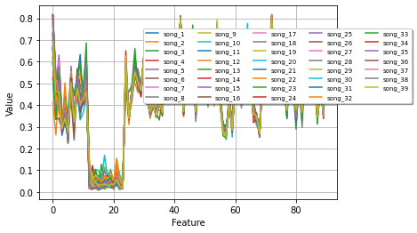

```python
for i in range(1,40):
    plt.plot(X_train[i], label='song_' + str(i))

plt.xlabel("Feature")
plt.ylabel("Value")
plt.legend(loc='upper center', bbox_to_anchor=(0.8, 0.9), ncol=5, fancybox=True, shadow=True, fontsize=7)
```

```python
# PCA
```

```python
def c_variance(x):
    total=0
    clist=[]
    for i in np.arange(0,X_train.shape[1]):
        p=PCA(n_components=i+1)
        p.fit(x)
        total=total+p.explained_variance_ratio_[i]
        clist.append(total)

    return clist
x_train_variance=list(map(lambda x:x*100,c_variance(X_train)))
```

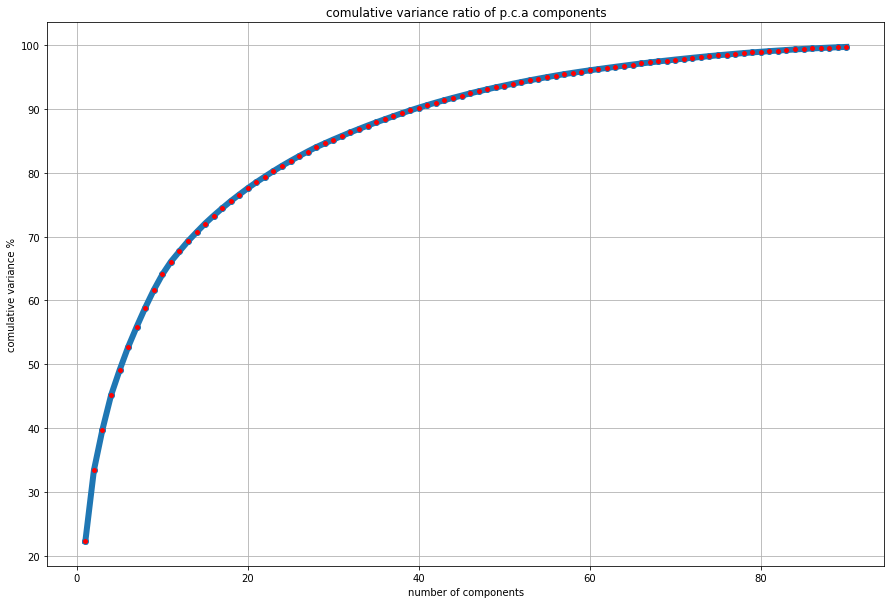

```python
plt.figure(figsize=(15,10))
plt.plot(np.arange(1,X_train.shape[1]+1),x_train_variance,marker='o',markerfacecolor='red',lw=6)
plt.xlabel('number of components')
plt.ylabel('comulative variance %')
plt.title('comulative variance ratio of p.c.a components')
```

```python
pca = PCA(n_components=20).fit(X_train)
X_pca = pca.transform(X_train)
```

## MODEL

Lets train some models

```python
#LOGISTIC REGRESSION
```

```python
clf3 = LogisticRegression()
clf3.fit(X_train, y_train)
predicted3 = clf3.predict(X_test)
```

```python
predicted3=predicted3.round()
cnf_matrix3 = metrics.confusion_matrix(y_test, predicted3)
```

```python
a1 = accuracy_score(y_test, predicted3)
a1
```

```
0.07627348440828975
```

We are gonna create a list to recuperate all the accuracy to compare the model at the end

```python
all_acc = {"Acc_logistic", "Acc_DT", "Acc_NN", "Acc_NN_grouped","Acc_logistic_grouped"}
```

```python
#DECISION TREE
```

```python
clf4 = DecisionTreeRegressor()
clf4.fit(X_train, y_train)
predicted4 = clf4.predict(X_test)
```

```python
predicted4 = predicted4.round()
cnf_matrix4 = metrics.confusion_matrix(y_test, predicted4)
```

```python
a2 = accuracy_score(y_test, predicted4)
a2
```

```
0.05556846794499322
```

```python
#Neural net
```

```python
# Our deep learning library is Keras

from keras import models
from keras import layers
from keras.models import Sequential
from keras.layers.core import Dense, Dropout
from keras.models import load_model
from keras.regularizers import l2
from keras.utils import np_utils
import numpy as np
# fixed random seed for reproducibility
np.random.seed(0)
import sys
sys.path.append("c:/ml/lib")
from tensorflow.python.keras.callbacks import ReduceLROnPlateau, EarlyStopping
from keras.optimizers import RMSprop
from keras.wrappers.scikit_learn import KerasClassifier
from sklearn.pipeline import Pipeline
from sklearn.model_selection import GridSearchCV
from sklearn.feature_extraction.text import TfidfVectorizer
from sklearn.preprocessing import StandardScaler
```

```python
#X_test.shape[0]
Y_train = np_utils.to_categorical(y_train, 90)
Y_test = np_utils.to_categorical(y_test, 90)
```

```python
# Our first Keras Model
model1 = Sequential()
model1.add(Dense(90, input_shape=(90,), activation='tanh'))
model1.add(Dense(110, activation='tanh'))
model1.add(Dropout(0.2))
model1.add(Dense(90, activation='sigmoid'))
```

```python
model1.compile(loss='binary_crossentropy', optimizer='Adam', metrics=['accuracy'])
```

```python
h1=model1.fit(
    X_train,
    Y_train,
    batch_size=64,
    epochs=5,
    validation_data=(X_test, Y_test)
)
```

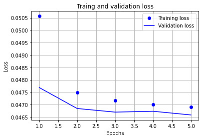

```python
history_dict = h1.history
loss_values = history_dict['loss']
val_loss_values = history_dict['val_loss']

epochs = range(1, 5 + 1)

plt.plot(epochs, loss_values, 'bo', label = 'Training loss')
plt.plot(epochs, val_loss_values, 'b', label = 'Validation loss')
plt.title('Traing and validation loss')
plt.xlabel('Epochs')
plt.ylabel('Loss')
plt.legend()

plt.show()
```

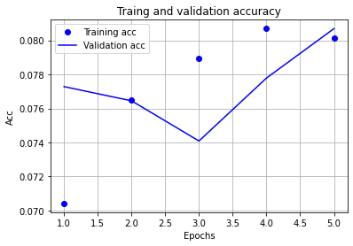

```python
plt.clf()
acc_values = history_dict['accuracy']
val_acc_values = history_dict['val_accuracy']

epochs = range(1, 5 + 1)

plt.plot(epochs, acc_values, 'bo', label = 'Training acc')
plt.plot(epochs, val_acc_values, 'b', label = 'Validation acc')
plt.title('Traing and validation accuracy')
plt.xlabel('Epochs')
plt.ylabel('Acc')
plt.legend()

plt.show()
```

```python
P = model1.predict_classes(X_test)
P
```

```
array([83, 85, 85, ..., 85, 85, 85])
```

```python
cnf_matrix8 = metrics.confusion_matrix(y_test, P)
a3 = accuracy_score(y_test, P)
a3
```

```
0.08068952159597133
```

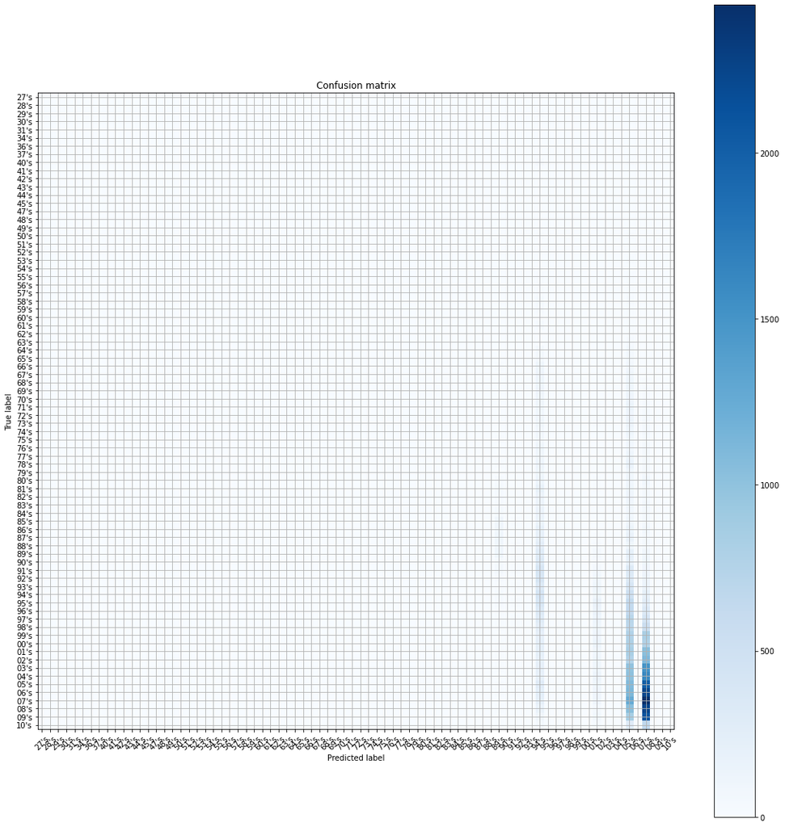

```python
def plot_confusion_matrix(cm, classes,
                          normalize=False,
                          title='Confusion matrix',
                          cmap=plt.cm.Blues):
    """
    This function prints and plots the confusion matrix.
    Normalization can be applied by setting `normalize=True`.
    """
    if normalize:
        cm = cm.astype('float') / cm.sum(axis=1)[:, np.newaxis]

    plt.imshow(cm, interpolation='nearest', cmap=cmap)
    plt.title(title)
    plt.colorbar()
    tick_marks = np.arange(len(classes))
    plt.xticks(tick_marks, classes, rotation=45)
    plt.yticks(tick_marks, classes)

    fmt = '.2f' if normalize else 'd'
    thresh = cm.max() / 2.

    plt.tight_layout()
    plt.ylabel('True label')
    plt.xlabel('Predicted label')

# Compute confusion matrix
np.set_printoptions(precision=2)

# Plot non-normalized confusion matrix
plt.figure()
fig, ax = plt.subplots(figsize=(15,15))
labels = sorted(Test.year.unique())
plot_confusion_matrix(cnf_matrix8, classes=["{:02d}'s".format(label%100) for label in labels],
                      title='Confusion matrix')


plt.show()
```

For all the previous model, the results are pretty lame if we can saySo we are gonna try something else : prediction by group of year

```python
# separate train attributes and test into different dataframes
Xg = data.grouped.iloc[:,1:]
Yg = data.grouped.iloc[:,0]
Yg = Yg - Yg.min()

Traing = data.grouped.iloc[0:463715]
Testg = data.grouped.iloc[463715:]

# Train set
X_traing = Xg.iloc[0:463715].values
y_traing = Yg.iloc[0:463715].values

# Validation set
X_testg = Xg.iloc[463715:].values
y_testg = Yg.iloc[463715:].values
print("Train grouped : X ", X_traing.shape, ", Y ", y_traing.shape)
print("Test grouped: X ", X_testg.shape, ", Y ", y_testg.shape)
```

```
Train grouped : X  (463715, 90) , Y  (463715,)
Test grouped: X  (51630, 90) , Y  (51630,)
```

```python
Y_traing = np_utils.to_categorical(y_traing-1, 90)
Y_testg = np_utils.to_categorical(y_testg-1, 90)
```

We are gonna make gridsearchs to look for the best parameters

```python
def create_model(optimizer="RMSprop",loss ='binary_crossentropy' ):
    model = Sequential()
    model.add(Dense(90, input_shape=(90,), activation='relu'))
    model.add(Dense(110, activation='relu'))
    model.add(Dropout(0.2))
    model.add(Dense(90, activation='sigmoid'))
    model.compile(loss=loss, optimizer=optimizer,metrics=["accuracy"])
    return model
```

```python
kears_estimator = KerasClassifier(build_fn=create_model, verbose=1, epochs = 5, batch_size = 64)
```

```python
# Define the grid search parameters
param_grid = dict(loss = ['categorical_crossentropy','binary_crossentropy','sparse_categorical_crossentropy'],
                 optimizer = ['SGD','RMSprop','Adagrad','Adadelta','Adam'])
```

```python
grid = GridSearchCV(estimator=kears_estimator,
                    param_grid=param_grid,)
```

```python
grid_result = grid.fit(X_traing, Y_traing )

# summarize results
print("Best: %f using %s" % (grid_result.best_score_, grid_result.best_params_))
```

[output not shown]

[output not shown]

[output not shown]

[output not shown]

[output not shown]

[output not shown]

[output not shown]

[output not shown]

[output not shown]

[output not shown]

[output not shown]

[output not shown]

[output not shown]

[output not shown]

[output not shown]

[output not shown]

[output not shown]

[output not shown]

[output not shown]

[output not shown]

[output not shown]

[output not shown]

[output not shown]

[output not shown]

[output not shown]

```
Best: 0.620853 using {'loss': 'binary_crossentropy', 'optimizer': 'Adam'}
```

```python
def create_model2(activation='relu'):
    model = Sequential()
    model.add(Dense(90, input_shape=(90,), activation=activation))
    model.add(Dense(110, activation=activation))
    model.add(Dropout(0.2))
    model.add(Dense(90, activation='sigmoid'))
    model.compile(loss='binary_crossentropy', optimizer='Adam',metrics=["accuracy"])
    return model
```

```python
kears_estimator2 = KerasClassifier(build_fn=create_model2, verbose=1, epochs = 5, batch_size = 64)
```

```python
# Define the grid search parameters
param_grid2 = dict(activation = ['softmax', 'softplus', 'softsign', 'relu', 'tanh', 'sigmoid', 'hard_sigmoid', 'linear'])
```

```python
grid2 = GridSearchCV(estimator=kears_estimator2,
                    param_grid=param_grid2,)
```

```python
grid_result2 = grid2.fit(X_traing, Y_traing )

# summarize results
print("Best: %f using %s" % (grid_result2.best_score_, grid_result2.best_params_))
```

```
Best: 0.619212 using {'activation': 'tanh'}
```

Considering the two results of our gridsearch, we are gonna use the 'tanh' activation, the 'Adam' optimizer and the binary_crossentropy loss function

```python
model3 = Sequential()
model3.add(Dense(90, input_shape=(90,), activation='tanh'))
model3.add(Dense(110, activation='tanh'))
model3.add(Dropout(0.2))
model3.add(Dense(90, activation='sigmoid'))
```

```python
model3.compile(loss='binary_crossentropy', optimizer='Adam', metrics=['accuracy'])
```

```python
h3=model3.fit(
    X_traing,
    Y_traing,
    batch_size=64,
    epochs=5,
    validation_data=(X_testg, Y_testg)
)
```

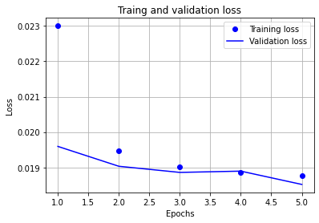

```python
history_dict = h3.history
loss_values = history_dict['loss']
val_loss_values = history_dict['val_loss']

epochs = range(1, 5 + 1)

plt.plot(epochs, loss_values, 'bo', label = 'Training loss')
plt.plot(epochs, val_loss_values, 'b', label = 'Validation loss')
plt.title('Traing and validation loss')
plt.xlabel('Epochs')
plt.ylabel('Loss')
plt.legend()

plt.show()
```

The loss function seems pretty good, even the validation function loss, there is'nt any pic

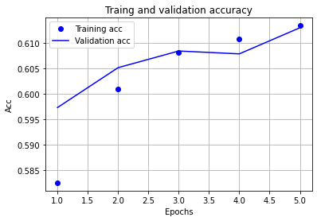

```python
plt.clf()
acc_values = history_dict['accuracy']
val_acc_values = history_dict['val_accuracy']

epochs = range(1, 5 + 1)

plt.plot(epochs, acc_values, 'bo', label = 'Training acc')
plt.plot(epochs, val_acc_values, 'b', label = 'Validation acc')
plt.title('Traing and validation accuracy')
plt.xlabel('Epochs')
plt.ylabel('Acc')
plt.legend()

plt.show()
```

The training accuracy is way more better now, the validation accuracy is quite good too, it follows the training accuracy

```python
P3 = model3.predict_classes(X_testg)
P3 = P3 + 1
P3
```

```
array([80, 80, 80, ..., 80, 80, 80])
```

```python
cnf_matrix10 = metrics.confusion_matrix(y_testg, P3)
a4 = accuracy_score(y_testg, P3)
a4
```

```
0.6129769513848538
```

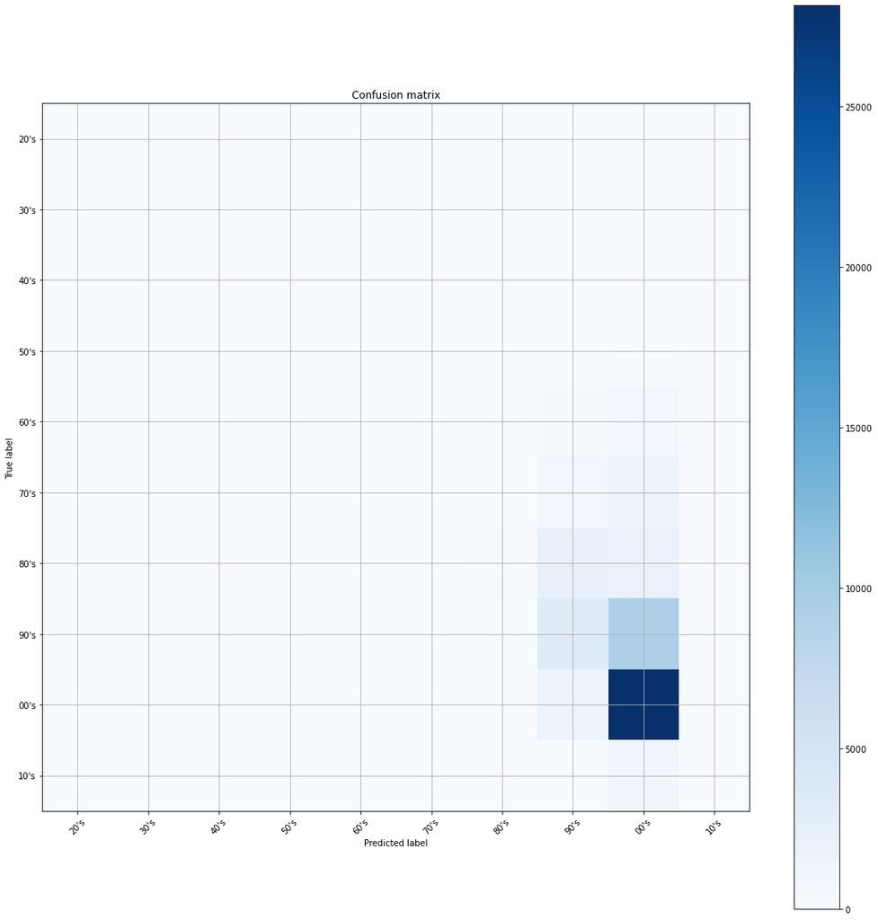

```python
def plot_confusion_matrix(cm, classes,
                          normalize=False,
                          title='Confusion matrix',
                          cmap=plt.cm.Blues):
    """
    This function prints and plots the confusion matrix.
    Normalization can be applied by setting `normalize=True`.
    """
    if normalize:
        cm = cm.astype('float') / cm.sum(axis=1)[:, np.newaxis]

    plt.imshow(cm, interpolation='nearest', cmap=cmap)
    plt.title(title)
    plt.colorbar()
    tick_marks = np.arange(len(classes))
    plt.xticks(tick_marks, classes, rotation=45)
    plt.yticks(tick_marks, classes)

    fmt = '.2f' if normalize else 'd'
    thresh = cm.max() / 2.

    plt.tight_layout()
    plt.ylabel('True label')
    plt.xlabel('Predicted label')

# Compute confusion matrix
np.set_printoptions(precision=2)

# Plot non-normalized confusion matrix
plt.figure()
fig, ax = plt.subplots(figsize=(15,15))
labels = sorted(Testg.year.unique())
plot_confusion_matrix(cnf_matrix10, classes=["{:02d}'s".format(label%100) for label in labels],
                      title='Confusion matrix')


plt.show()
```

```python
clf3 = LogisticRegression()
clf3.fit(X_traing, y_traing)
predicted3 = clf3.predict(X_testg)
```

```python
predicted3=predicted3.round()
cnf_matrix3 = metrics.confusion_matrix(y_testg, predicted3)
```

```python
a5 = accuracy_score(y_testg, predicted3)
a5
```

```
0.6014332752275808
```

The result is pretty close to the one from the neural network

```python
all_acc = {"Acc_logistic":a1, "Acc_DT":a2, "Acc_NN":a3, "Acc_NN_grouped":a4,"Acc_logistic_grouped":a5}
```

```
<BarContainer object of 5 artists>
```

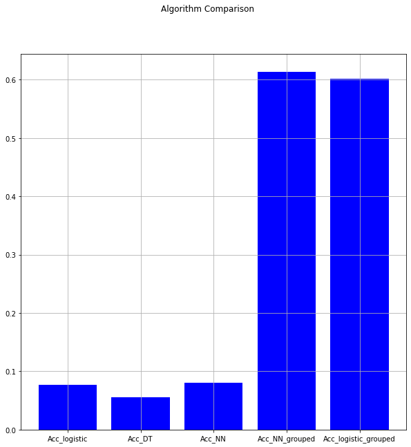

```python
fig, ax = plt.subplots(figsize=(10,10))
fig.suptitle('Algorithm Comparison')
plt.bar(all_acc.keys(), all_acc.values(),  color='b')
```